# 語言心理學經典實驗介紹

2020-10-23

## 單元說明

- 語言心理學的研究範圍
- 語音知覺與反應時間
- 心智詞彙網路的理論
- 詞彙判斷作業的證據
- 句子理解的理論
- 形態匹配效應的證據

## 語言心理學四大研究方向

1. 兒童如何習得語言？
2. 成人如何理解語言？
3. 成人如何產製語言？
4. 人類如何學習母語之外的語言？

更多介紹請見[教材](https://scgeeker.github.io/EXPPSY_Opensci/language.html)

## 語言心理學的重要主題

- 語音學(Phonetics)
- 構詞學(Morphology)
- 語法學(Syntax)
- 語義學(Semantics)
- 語用學(Pragmatics)

Crash Course的[語言學入門](https://www.youtube.com/playlist?list=PL8dPuuaLjXtP5mp25nStsuDzk2blncJDW)

## 語音知覺實驗範例

- [辨認發聲者的性別](https://voiceresearch.org/)(Voice Research lab by David Feinberg)

## 聲帶寬度與音高

參考[維基百科：聲帶](https://en.wikipedia.org/wiki/Vocal_cords)

[figure not shown]

## 人類的發聲器官

參考[維基百科：發聲器官](https://en.wikipedia.org/wiki/Articulatory_phonetics)

[figure not shown]

## 人類發聲的反應時間計時

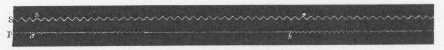

(跳躍一百年)

## 心智詞彙網路(Mental Lexical Network)

[figure not shown]

Collins and Quillian (1969)

## 主題文獻

- 關聯性促發效應： Meyer and Schvaneveldt (1971) [論文下載](https://osf.io/bukg3/)
- 詞頻效應與重覆效應： Forster and Davis (1984) [論文下載](https://osf.io/xp59g/)

## 詞彙判斷作業

- 促發程序LDT:測量看過相關字詞後，辨識目標字詞的反應時間，測量關聯性促發效應
- 單詞版LDT:測量辨識字詞的反應時間，測量詞頻效應
- 重覆程序LDT:測量辨識字詞的反應時間，有兩個段落，測量重覆效應

(結束後自行複製貼上到Excel或google sheet)  
(促發程序LDT實驗分析資料示範請見下一張)

## 原始資料範例

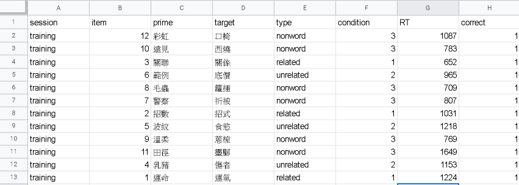

## 個別受試者資料處理

in google sheet: `Data -> Pivot Table`

`Rows`: condition  
`Values`: RT  
`Filters`: correct = 1

## 多位受試者資料處理

來源： Zwaan et al. (2017)

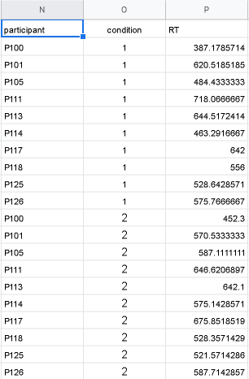

## 擴散激發(Spreading Activation)

[figure not shown]

Collins and Loftus (1975)

## 語義特徵模型(Semantic Features Model)

[figure not shown]

Smith, Shoben, and Rips (1974)

## 如何解釋關聯性促發效應

- (**主張**)相關的字詞概念在心智詞彙網路彼此連結。剛被提取的概念經由擴散激發提高有連結的項目被提取的效率，連結越強的項目越容易被提取。
- (**方法**) Meyer and Schvaneveldt (1971) 操作促發字詞與目標字詞的語義關聯性，測量兩種字詞組合的詞彙判斷作業反應差異。
- (**預測**) 有關聯性促發詞與目標詞嘗試反應時間，會顯著比無關聯性促發詞與目標詞嘗試反應時間短。

## 在重製中思考關聯性促發效應

- 參考[習作](https://scgeeker.github.io/EXPPSY_Opensci/language.html#lang_practice)
- Zwaan et al. (2017) 進行的重覆效應來自 Meyer and Schvaneveldt (1971) 的那一個實驗？運用Replication Plan格式檢視兩項研究的細節。請嘗試運用 Zwaan et al. (2017) 的公開資料，探討兩項研究測量重覆效應的條件差異？

## 詞頻效應(Word Frequency Effect)

- 根據語言資料庫，統計字詞出現次數，研究者可選擇做為實驗材料的字詞屬於高詞頻(High Frequency)或低詞頻(Low Frequency)。
- 可能的解釋：高詞頻字詞有較多語義表徵，相對低詞頻字詞比較容易提取。
- Forster and Davis (1984) 設計單一目標詞的詞彙判斷作業，測試重覆字詞會如何改變高詞頻及低詞頻字詞的反應速度。

[figure not shown]

取自Brysbaert, Keuleers, Mandera, and Mandera (2014)

## 重覆效應(Repetition Effect)

- (**主張**)高詞頻字詞短時間內被提取一次，再次提取能貢獻的反應助益，明顯小於低詞頻字詞。
- (**方法**) Forster and Davis (1984) 安排兩段詞彙判斷作業，第一段曾出現的字詞，其中一部分在第二段再次呈現。比較第一段有出現的字詞與沒有出現的字詞之反應差異。
- (**預測**) 曾在第一段出現的低詞頻字詞，在第二段的反應時間減少程度顯著大於高詞頻字詞。

## 在重製中思考重覆效應

- 參考[習作](https://scgeeker.github.io/EXPPSY_Opensci/language.html#lang_practice)
- Zwaan et al. (2017) 進行的重覆效應來自 Forster and Davis (1984) 的那一個實驗？運用Replication Plan格式檢視兩項研究的細節。請嘗試運用 Zwaan et al. (2017) 的公開資料，探討兩項研究測量重覆效應的條件差異？

## 句子理解的兩種理論

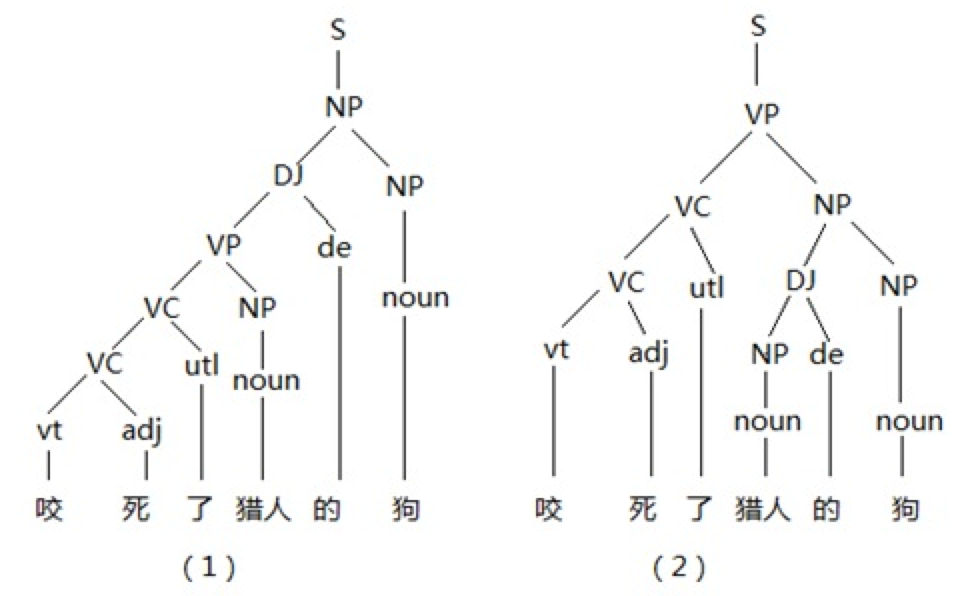

句法結構理論

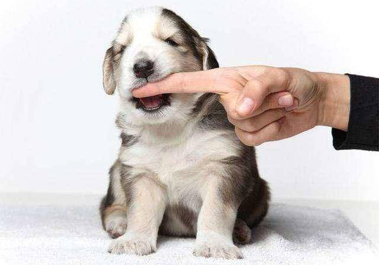

心像理論

## 主題文獻

- 形態匹配效應： Zwaan, Stanfield, and Yaxley (2002) [論文下載](https://osf.io/7y5fb/)

## 心像理論的假設

- (**主張**)目標圖中的物件型態，如果越符合從前導句聯想到的物件心像，讀者越容易做出快且正確的反應。
- (**方法**) Zwaan, Stanfield, and Yaxley (2002) 安排數種句子與物件圖像，每一種都有兩組型態相符的配對，交換即成為不相符的配對。經由隨機分派，同一張圖像可獲得相符與不相符的反應資料。比較相符圖像的反應時間與不相符圖像的反應時間。
- (**預測**) 相符圖像的反應時間會顯著短於不相符圖像的反應時間。

## 句圖比對作業

簡易示範。請了解程序之後再開始進行12項嘗試實驗。

## 實驗設計

[figure not shown]

相符 vs. 不相符的句子與圖像

## 形態匹配效應

Zwaan et al. (2017) 再現實驗結果

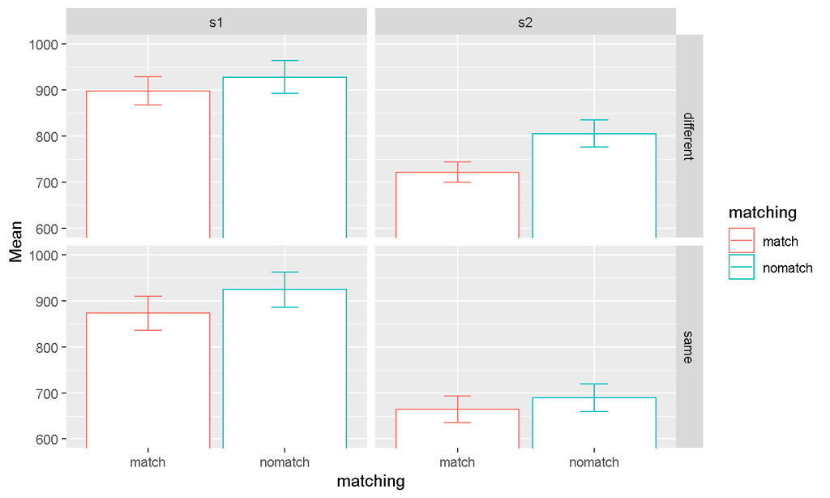

## 在重製中思考形態模擬效應

- 參考[習作](https://scgeeker.github.io/EXPPSY_Opensci/language.html#lang_practice)
- Zwaan et al. (2017) 進行的重覆效應來自 Zwaan, Stanfield, and Yaxley (2002) 的那一個實驗？請運用Replication Plan格式檢視兩項研究的細節。請嘗試運用 Zwaan et al. (2017) 的公開資料，探討兩項研究測量重覆效應的條件差異？

## 參考文獻

Collins, Allan M., and Elizabeth F. Loftus. 1975. “A Spreading-Activation Theory of Semantic Processing.” *Psychological Review* 82 (6): 407–28. https://doi.org/10.1037/0033-295X.82.6.407.

Collins, Allan M., and M. Ross Quillian. 1969. “Retrieval Time from Semantic Memory.” *Journal of Verbal Learning and Verbal Behavior* 8 (2): 240–47. https://doi.org/10.1016/S0022-5371(69)80069-1.

Forster, Kenneth, and Chris Davis. 1984. “Repetition Priming and Frequency Attenuation in Lexical Access.” *Journal of Experimental Psychology: Learning, Memory, and Cognition* 10 (4): 680–98. https://doi.org/10.1037/0278-7393.10.4.680.

Meyer, David E., and Roger W. Schvaneveldt. 1971. “Facilitation in Recognizing Pairs of Words: Evidence of a Dependence Between Retrieval Operations.” *Journal of Experimental Psychology* 90 (2): 227–34. https://doi.org/10.1037/h0031564.

Smith, Edward E., Edward J. Shoben, and Lance J. Rips. 1974. “Structure and Process in Semantic Memory: A Featural Model for Semantic Decisions.” *Psychological Review* 81 (3): 214–41. https://doi.org/10.1037/h0036351.

Zwaan, Rolf A., Diane Pecher, Gabriele Paolacci, Samantha Bouwmeester, Peter Verkoeijen, Katinka Dijkstra, and René Zeelenberg. 2017. “Participant Nonnaiveté and the Reproducibility of Cognitive Psychology.” *Psychonomic Bulletin & Review*, July, 1–5. https://doi.org/10.3758/s13423-017-1348-y.

Zwaan, Rolf A., Robert A. Stanfield, and Richard H. Yaxley. 2002. “Language Comprehenders Mentally Represent the Shapes of Objects.” *Psychological Science* 13 (March): 168–71. https://doi.org/10.1111/1467-9280.00430.